# Date estimation analysis

[Script run 2019-04-12 20:04:58]

## Load data

### Clean data

Sane responses fulfil all:

- estimate (1825, 1975)
- after <= estimate
- before >= estimate
- after >= 1800
- before <= 2000

| Var1 | Freq |
| --- | --- |
| TRUE | 1297 |
| Estimate out of range | 50 |
| After out of range | 0 |
| Before out of range | 0 |
| After after estimate | 5 |
| Before before estimate | 150 |

## Participants performance

|  | id | questionCount | hitRate | bracketRate | goodAnswerRate | meanError | sdError | meanBracketWidth | sdBracketWidth | meanRT | hard_easy | dull_fun | tooLong_tooShort |
| --- | --- | --- | --- | --- | --- | --- | --- | --- | --- | --- | --- | --- | --- |
| 7fcd3d66 | 7fcd3d66 | 50.00 | 0.50 | 0.90 | 1.00 | 2.82 | 6.62 | 11.04 | 7.48 | 21441.08 | 0.19 | 0.95 | 0.62 |
| 5020c3c4 | 5020c3c4 | 50.00 | 0.60 | 0.88 | 1.00 | 2.28 | 5.72 | 7.50 | 2.59 | 30478.08 | 0.60 | 0.97 | 0.06 |
| 5947d8d3 | 5947d8d3 | 50.00 | 0.04 | 0.82 | 0.92 | 30.36 | 28.56 | 120.34 | 63.64 | 8680.74 | 0.28 | 0.30 | 0.50 |
| b33a56f6 | b33a56f6 | 50.00 | 0.22 | 0.70 | 0.98 | 14.02 | 20.01 | 29.76 | 21.64 | 36476.80 | 0.03 | 1.00 | 0.50 |
| 9b7bc075 | 9b7bc075 | 50.00 | 0.10 | 0.70 | 1.00 | 19.34 | 24.07 | 45.90 | 23.97 | 28173.60 | 0.28 | 0.41 | 0.40 |
| 9bfa7fd9 | 9bfa7fd9 | 50.00 | 0.08 | 0.70 | 0.96 | 22.34 | 24.72 | 48.06 | 30.62 | 22294.46 | 0.39 | 1.00 | 0.51 |
| 394d747f | 394d747f | 50.00 | 0.04 | 0.70 | 0.84 | 27.64 | 27.16 | 48.26 | 26.38 | 18314.80 | 0.80 | 0.20 | 0.50 |
| 24f499bc | 24f499bc | 50.00 | 0.06 | 0.68 | 0.90 | 24.96 | 31.14 | 48.80 | 23.45 | 33803.64 | 0.26 | 0.50 | 0.50 |
| bc66efa6 | bc66efa6 | 50.00 | 0.02 | 0.56 | 0.98 | 25.10 | 20.41 | 42.24 | 25.73 | 12814.12 | 0.00 | 0.76 | 0.31 |
| 5b71f2b9 | 5b71f2b9 | 50.00 | 0.04 | 0.54 | 1.00 | 27.76 | 19.28 | 51.00 | 30.53 | 16651.02 | 0.15 | 0.60 | 0.34 |
| 0 | 0 | 50.00 | 0.16 | 0.52 | 1.00 | 19.28 | 20.86 | 33.02 | 29.98 | 13644.78 | 0.24 | 0.88 | 0.56 |
| 8ffbf531 | 8ffbf531 | 50.00 | 0.02 | 0.50 | 1.00 | 29.68 | 23.43 | 51.58 | 29.15 | 23922.22 | 0.53 | 0.84 | 0.53 |
| c98ca538 | c98ca538 | 50.00 | 0.00 | 0.50 | 1.00 | 25.80 | 23.21 | 37.22 | 23.00 | 14959.72 | 0.75 | 0.73 | 0.35 |
| 0a4f725a | 0a4f725a | 50.00 | 0.04 | 0.48 | 0.90 | 38.00 | 28.59 | 48.26 | 28.13 | 54308.00 | 0.00 | 0.62 | 0.16 |
| 2a8099d5 | 2a8099d5 | 50.00 | 0.00 | 0.48 | 0.98 | 27.16 | 22.17 | 42.60 | 26.31 | 41424.52 | 0.02 | 0.12 | 0.45 |
| 366bd308 | 366bd308 | 50.00 | 0.00 | 0.46 | 1.00 | 37.62 | 25.84 | 58.10 | 18.68 | 26626.02 | 0.13 | 0.47 | 0.36 |
| be847eeb | be847eeb | 50.00 | 0.02 | 0.44 | 0.98 | 37.08 | 24.49 | 59.48 | 53.35 | 12960.20 | 0.09 | 0.37 | 0.17 |
| ceedbccb | ceedbccb | 50.00 | 0.02 | 0.40 | 0.98 | 42.02 | 29.81 | 49.80 | 26.84 | 13440.14 | 0.00 | 0.13 | 0.16 |
| d2b603b3 | d2b603b3 | 50.00 | 0.08 | 0.38 | 1.00 | 19.76 | 18.39 | 24.10 | 17.21 | 12623.88 | 0.28 | 0.61 | 0.45 |
| ecfcbd9c | ecfcbd9c | 50.00 | 0.04 | 0.34 | 1.00 | 32.74 | 23.17 | 36.50 | 12.57 | 15567.76 | 0.02 | 0.79 | 0.65 |
| c3f65a69 | c3f65a69 | 50.00 | 0.00 | 0.32 | 1.00 | 34.48 | 25.99 | 34.28 | 15.33 | 30556.44 | 0.17 | 0.60 | 0.46 |
| fc0888e2 | fc0888e2 | 50.00 | 0.00 | 0.30 | 0.76 | 44.02 | 35.95 | 33.32 | 23.40 | 15685.54 | 0.00 | 0.00 | 0.41 |
| 854fbf58 | 854fbf58 | 50.00 | 0.02 | 0.30 | 1.00 | 29.64 | 20.61 | 25.80 | 4.99 | 33218.24 | 0.13 | 0.62 | 0.17 |
| 58bc90ed | 58bc90ed | 50.00 | 0.02 | 0.24 | 0.90 | 34.46 | 29.20 | 15.40 | 8.12 | 38122.86 | 0.31 | 0.50 | 0.37 |
| cf3c4ec0 | cf3c4ec0 | 50.00 | 0.06 | 0.24 | 0.96 | 31.70 | 23.60 | 19.96 | 8.00 | 20604.88 | 0.00 | 0.59 | 0.43 |
| e6b691d4 | e6b691d4 | 50.00 | 0.06 | 0.20 | 0.78 | 34.66 | 31.06 | 11.32 | 6.09 | 52032.56 | 0.07 | 1.00 | 0.51 |
| 9cca7b06 | 9cca7b06 | 50.00 | 0.00 | 0.20 | 1.00 | 34.72 | 24.21 | 20.38 | 6.57 | 21784.40 | 0.43 | 0.67 | 0.57 |
| 741b6225 | 741b6225 | 50.00 | 0.00 | 0.06 | 0.10 | 37.04 | 23.51 | -22.86 | 18.55 | 21576.44 | 0.00 | 0.21 | 0.13 |
| a268e42d | a268e42d | 50.00 | 0.28 | 0.00 | 0.00 | 23.92 | 30.66 | -11.12 | 10.44 | 28000.98 | 0.09 | 1.00 | 0.29 |
| 7a4d72d5 | 7a4d72d5 | 2.00 | 0.00 | 0.00 | 0.50 | 42.50 | 14.85 | 22.00 | 39.60 | 88686.50 | NA | NA | NA |
| 739516c2 | 739516c2 | 50.00 | 0.06 | 0.00 | 0.00 | 29.36 | 23.92 | -12.62 | 6.99 | 20798.30 | 0.16 | 0.58 | 0.05 |

Before we remove outliers, we want a look at how the data stack up (so when we throw away data we know what we’re losing):

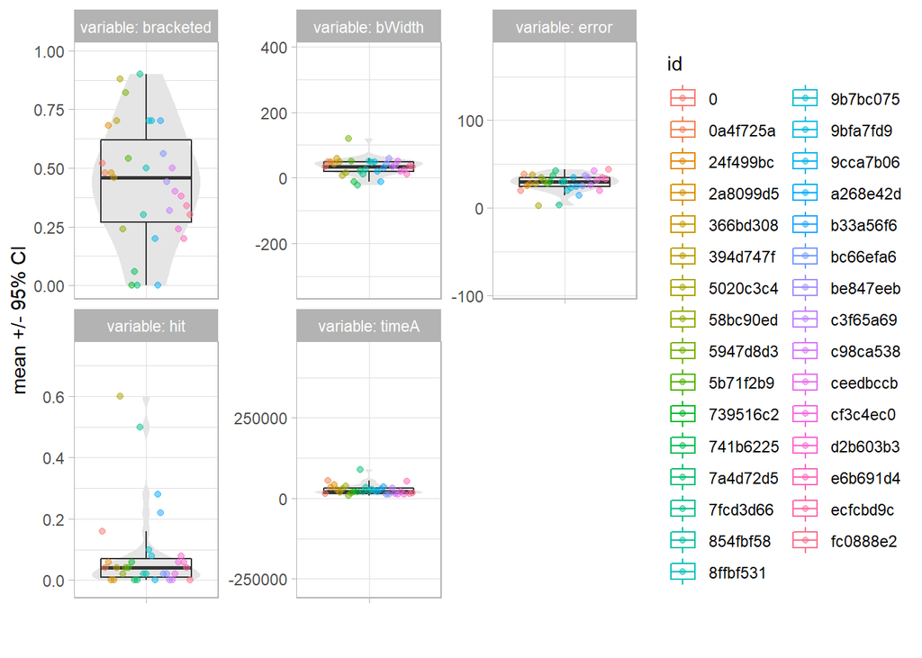

From here on down we remove invalid responses and participants who over- and underperformed.

First we drop the 1 participants who did the wrong number of questions.

Having removed those, we then remove the 2 participants with hitrate > 2SD away from the population mean, because they probably looked up the answers (this is not a throwaway; individual answers have been checked and suggest a pattern).

Finally, we remove the 1 participants with a mean bracket width > 2SD away from the population mean because they’re not easily comparable with the others.

With those participants removed, we can provide some general information about performance based on the 22 participants who remain:

| mean | sd | var |
| --- | --- | --- |
| 50.00 | 0.00 | questionCount |
| 0.05 | 0.06 | hitRate |
| 0.47 | 0.16 | bracketRate |
| 0.97 | 0.04 | goodAnswerRate |
| 28.88 | 7.22 | meanError |
| 24.11 | 3.52 | sdError |
| 39.57 | 12.78 | meanBracketWidth |
| 22.30 | 10.79 | sdBracketWidth |
| 24649.66 | 11275.95 | meanRT |
| 0.23 | 0.23 | hard_easy |
| 0.59 | 0.25 | dull_fun |
| 0.40 | 0.14 | tooLong_tooShort |

Having filtered out those who performed suspiciously, those who remain appear to have performed the task properly, getting few questions exactly right, answering almost all questions sensibly, and identifying the correct period approximately half the time.

### Performance overview

[figure not shown]

## Experiment feedback

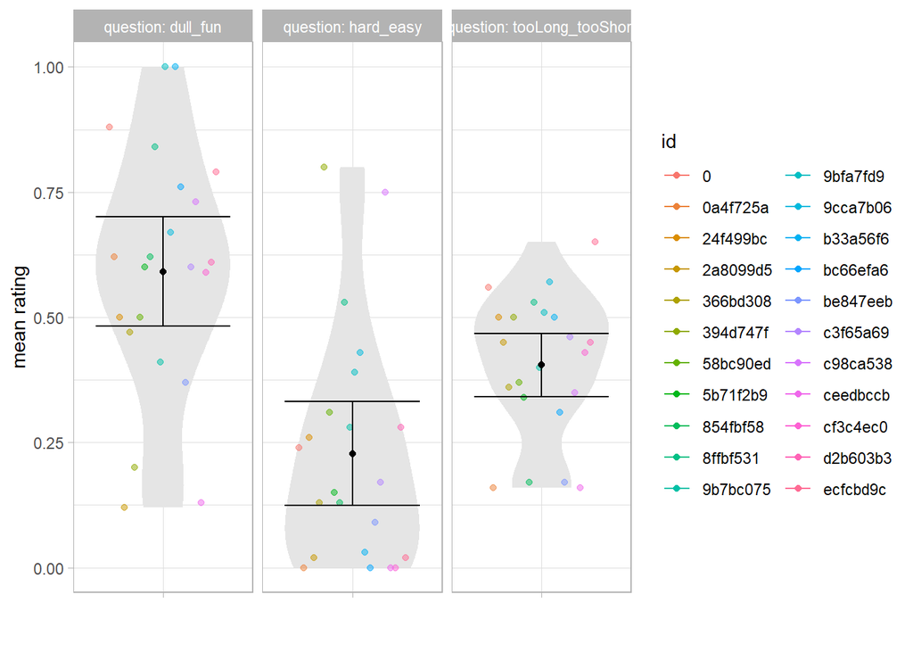

### Difficulty rating vs hit/bracket rate

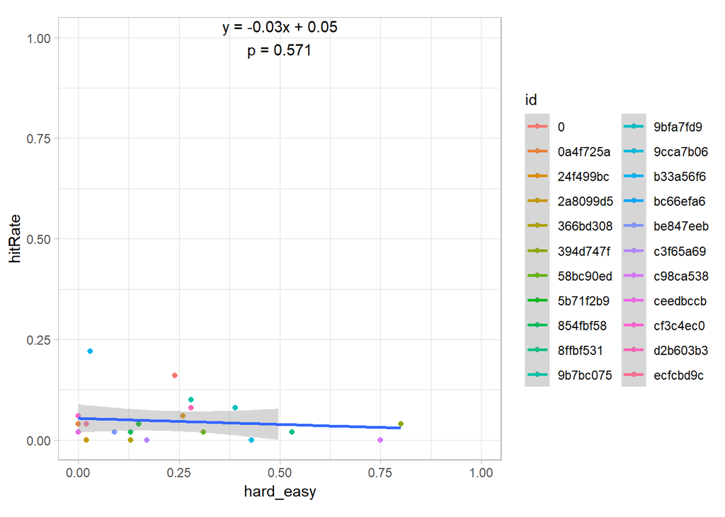

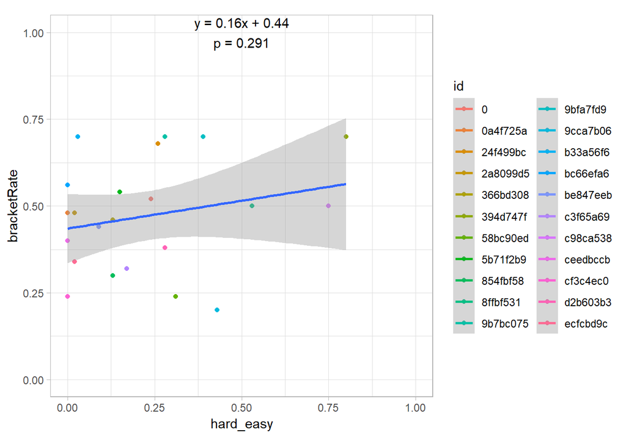

## Further performance investigations

### Bracket rate by bracket width

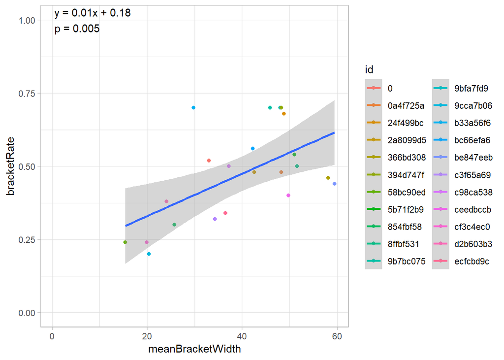

## Performance by item

Sorted by bracketed %, decreasing.

|  | qShort | target | topic | n | error.m | error.sd | timeA.m | timeA.sd | bracketed.m | bracketed.sd | bWidth.m | bWidth.sd | hit.m | hit.sd |
| --- | --- | --- | --- | --- | --- | --- | --- | --- | --- | --- | --- | --- | --- | --- |
| publication of Charl | publication of Charl | 1859.00 | science | 8.00 | 20.62 | 23.29 | 20347.00 | 9452.85 | 0.88 | 0.35 | 51.75 | 18.87 | 0.12 | 0.35 |
| the Federal Reserve | the Federal Reserve | 1913.00 | politics | 8.00 | 13.38 | 15.32 | 18530.88 | 8909.12 | 0.88 | 0.35 | 31.62 | 20.27 | 0.12 | 0.35 |
| Abraham Lincoln issu | Abraham Lincoln issu | 1863.00 | politics | 8.00 | 3.75 | 3.99 | 19748.88 | 9587.25 | 0.88 | 0.35 | 20.50 | 16.98 | 0.25 | 0.46 |
| Winston Churchill be | Winston Churchill be | 1940.00 | politics | 8.00 | 22.12 | 36.22 | 25352.88 | 25665.39 | 0.88 | 0.35 | 31.75 | 24.38 | 0.12 | 0.35 |
| nuclear bombs droppe | nuclear bombs droppe | 1945.00 | military | 7.00 | 14.43 | 35.56 | 26844.43 | 20606.01 | 0.86 | 0.38 | 12.43 | 11.10 | 0.43 | 0.53 |
| creation of the Nort | creation of the Nort | 1949.00 | military | 7.00 | 25.43 | 31.17 | 21147.00 | 14119.73 | 0.86 | 0.38 | 34.29 | 32.84 | 0.14 | 0.38 |
| Israel established a | Israel established a | 1948.00 | politics | 12.00 | 14.83 | 21.51 | 26316.58 | 29304.77 | 0.83 | 0.39 | 45.00 | 40.68 | 0.17 | 0.39 |
| October Revolution i | October Revolution i | 1917.00 | politics | 6.00 | 6.33 | 8.31 | 18969.17 | 7640.92 | 0.83 | 0.41 | 19.83 | 16.56 | 0.33 | 0.52 |
| World War I Armistic | World War I Armistic | 1918.00 | military | 6.00 | 10.33 | 20.95 | 21112.33 | 7152.96 | 0.83 | 0.41 | 24.33 | 36.55 | 0.17 | 0.41 |
| ’Father of Psycholog | ’Father of Psycholog | 1910.00 | science | 10.00 | 14.40 | 12.56 | 18915.30 | 13337.75 | 0.80 | 0.42 | 51.70 | 42.80 | 0.20 | 0.42 |
| volleyball invented | volleyball invented | 1895.00 | sport | 9.00 | 17.67 | 14.15 | 18258.33 | 11753.43 | 0.78 | 0.44 | 52.89 | 31.49 | 0.00 | 0.00 |
| American Civil War e | American Civil War e | 1865.00 | military | 13.00 | 21.31 | 27.70 | 22151.85 | 7595.54 | 0.77 | 0.44 | 32.46 | 22.03 | 0.15 | 0.38 |
| Vincent van Gogh die | Vincent van Gogh die | 1890.00 | arts | 12.00 | 13.25 | 16.29 | 27429.33 | 21264.51 | 0.75 | 0.45 | 38.58 | 24.98 | 0.33 | 0.49 |
| Karl Benz patents th | Karl Benz patents th | 1886.00 | technology | 8.00 | 10.00 | 6.41 | 15825.25 | 5350.62 | 0.75 | 0.46 | 27.50 | 10.69 | 0.00 | 0.00 |
| x-rays identified by | x-rays identified by | 1895.00 | science | 8.00 | 10.75 | 12.26 | 23036.62 | 10706.42 | 0.75 | 0.46 | 42.50 | 11.95 | 0.00 | 0.00 |
| Cuban achieves indep | Cuban achieves indep | 1898.00 | military | 7.00 | 32.14 | 20.51 | 27665.43 | 20284.79 | 0.71 | 0.49 | 50.00 | 28.28 | 0.00 | 0.00 |
| Joseph Stalin’s Grea | Joseph Stalin’s Grea | 1936.00 | politics | 10.00 | 17.90 | 16.43 | 23576.70 | 10502.60 | 0.70 | 0.48 | 31.60 | 17.28 | 0.00 | 0.00 |
| Eugene Burton Ely pe | Eugene Burton Ely pe | 1911.00 | technology | 10.00 | 16.70 | 14.41 | 26645.10 | 13511.56 | 0.70 | 0.48 | 38.20 | 22.81 | 0.00 | 0.00 |
| Tunguska event flatt | Tunguska event flatt | 1908.00 | science | 9.00 | 33.67 | 24.73 | 28888.78 | 24396.41 | 0.67 | 0.50 | 79.78 | 47.95 | 0.00 | 0.00 |
| the teddy bear is in | the teddy bear is in | 1903.00 | technology | 9.00 | 17.67 | 19.00 | 18038.78 | 6519.20 | 0.67 | 0.50 | 43.78 | 26.39 | 0.00 | 0.00 |
| Radium discovered by | Radium discovered by | 1898.00 | science | 9.00 | 20.67 | 17.88 | 20856.56 | 14860.40 | 0.67 | 0.50 | 44.44 | 26.51 | 0.00 | 0.00 |
| first photograph of | first photograph of | 1946.00 | technology | 6.00 | 18.17 | 13.11 | 35571.17 | 23290.69 | 0.67 | 0.52 | 32.00 | 14.76 | 0.00 | 0.00 |
| birth of Queen Eliza | birth of Queen Eliza | 1926.00 | politics | 6.00 | 4.67 | 5.05 | 39999.50 | 20571.57 | 0.67 | 0.52 | 18.83 | 11.29 | 0.17 | 0.41 |
| Frida Kahlo born | Frida Kahlo born | 1907.00 | arts | 11.00 | 11.64 | 11.67 | 29166.73 | 25845.68 | 0.64 | 0.50 | 41.00 | 34.68 | 0.18 | 0.40 |
| the Wall Street cras | the Wall Street cras | 1929.00 | politics | 11.00 | 11.27 | 14.80 | 21686.09 | 12900.70 | 0.64 | 0.50 | 28.55 | 28.10 | 0.18 | 0.40 |
| Ireland achieves ind | Ireland achieves ind | 1922.00 | military | 11.00 | 19.55 | 15.38 | 21930.36 | 7678.73 | 0.64 | 0.50 | 47.73 | 32.59 | 0.00 | 0.00 |
| foundation of the Mu | foundation of the Mu | 1928.00 | politics | 11.00 | 37.18 | 33.78 | 28519.09 | 17391.30 | 0.64 | 0.50 | 71.82 | 38.75 | 0.00 | 0.00 |
| basketball invented | basketball invented | 1891.00 | sport | 8.00 | 23.62 | 28.69 | 22443.75 | 18693.71 | 0.62 | 0.52 | 43.75 | 30.33 | 0.12 | 0.35 |
| Anglo-Zulu war in So | Anglo-Zulu war in So | 1879.00 | military | 10.00 | 17.90 | 19.91 | 27181.70 | 17975.99 | 0.60 | 0.52 | 33.90 | 18.25 | 0.00 | 0.00 |
| creation of the Brit | creation of the Brit | 1927.00 | politics | 10.00 | 20.00 | 20.39 | 31341.70 | 31954.86 | 0.60 | 0.52 | 50.50 | 39.68 | 0.00 | 0.00 |

[output cut: 85 more lines]

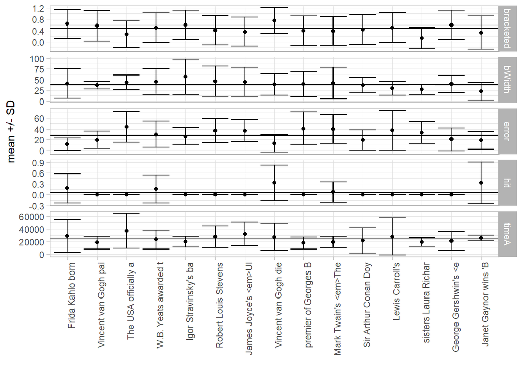

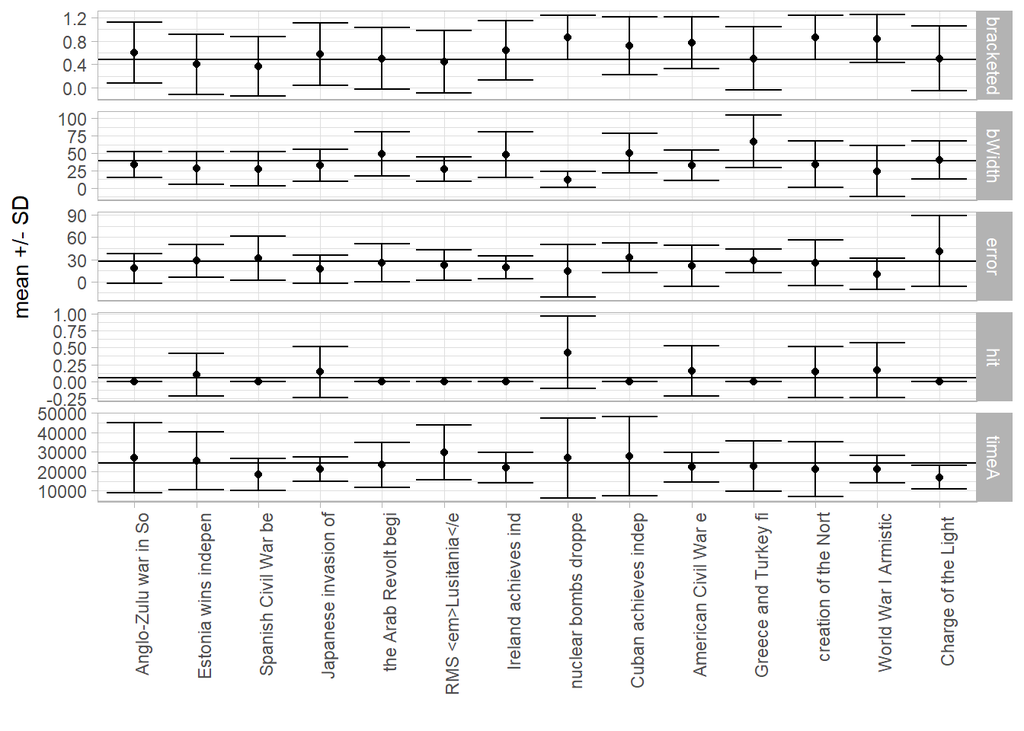

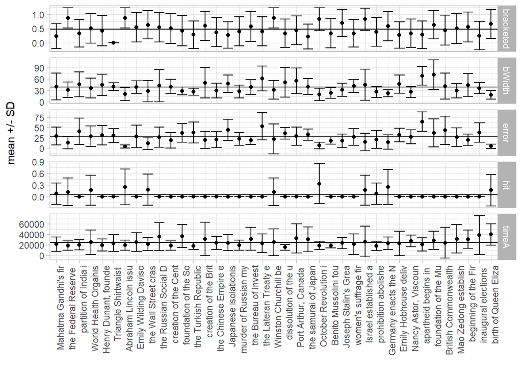

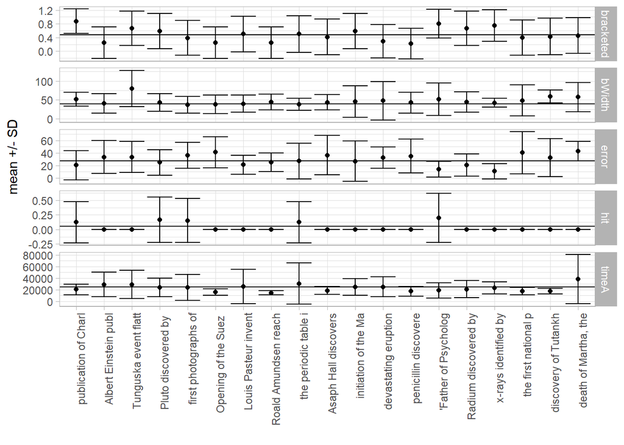

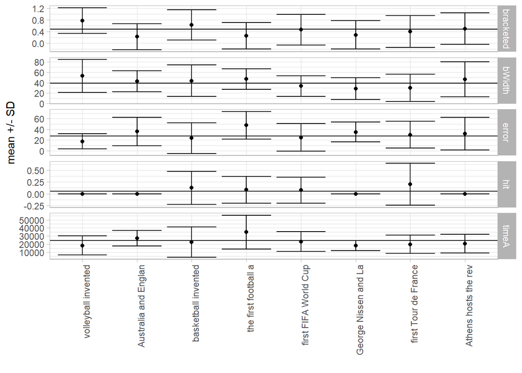

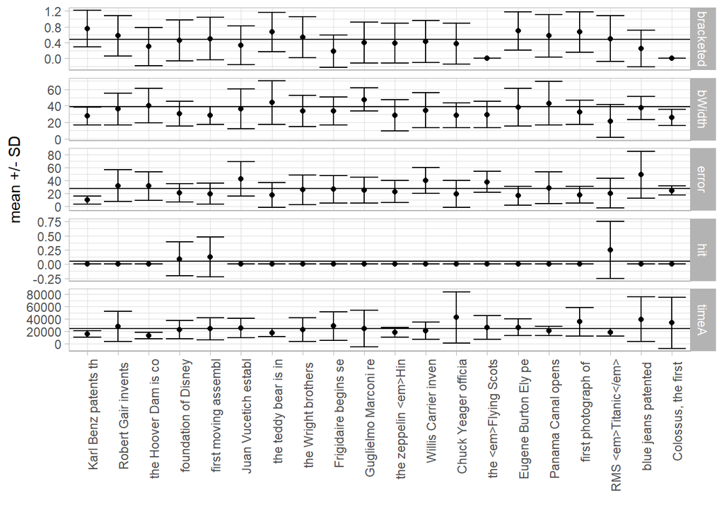

(This might look better rotated through 90 degrees)

### Recommended stimuli

We examine item performance in terms of response accuracy (hitrate), response times, bracketing rates (i.e. the proportion of participants for whom the event occurs between their ‘after’ and ‘before’ dates), and bracket widths (i.e. the distance between their ‘after’ and ‘before’ dates).

The intuitions about these measures are as follows:

- accuracy
- a high hit rate suggests that the answer is quite obvious; many participants ‘just know’ the answer
- bracketing widths on questions with high hit rates, and which a participant gets correct, may be indicative of a base level of confidence
- response times
- short response times can suggest extremes; either participants find the question very easy, or they know rapidly that they cannot sensibly guess at the answer
- long response times and high accuracy may indicate looking up the answers
- bracketing rates
- high bracketing rates indicate participants have a good sense of the general period in which something happened
- most usefully interpreted in conjunction with bracket widths
- bracket widths
- narrow bracket widths suggest that the period in which a date might occur is well known.
- in isolation, bracket widths are the best indicator of the difficulty of a question

Combining these, the best questions will have moderate response times and bracket widths, will have high bracketing rates, and will have accuracy rates which are not too high.

We can aim for something like:

- <= 33% accuracy
- >= 50% bracketing rate
- bracket widths and response times in the middle 50% of responses

| Var1 | Freq |
| --- | --- |
| accuracyTooHigh | 4 |
| bracketRateTooLow | 70 |
| bracketWidth<32.46 | 10 |
| bracketWidth>45 | 10 |
| rt<20960 | 3 |
| rt>27665.43 | 5 |
| TRUE | 13 |

### Individual item plots

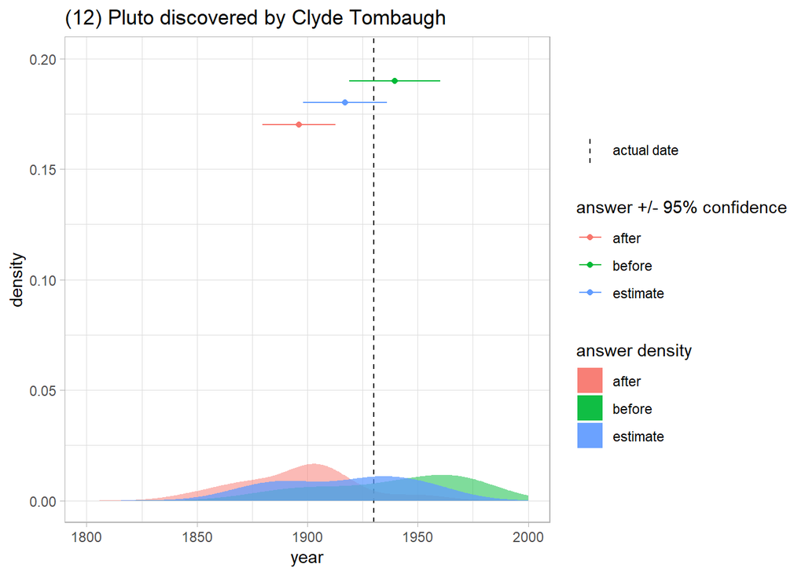

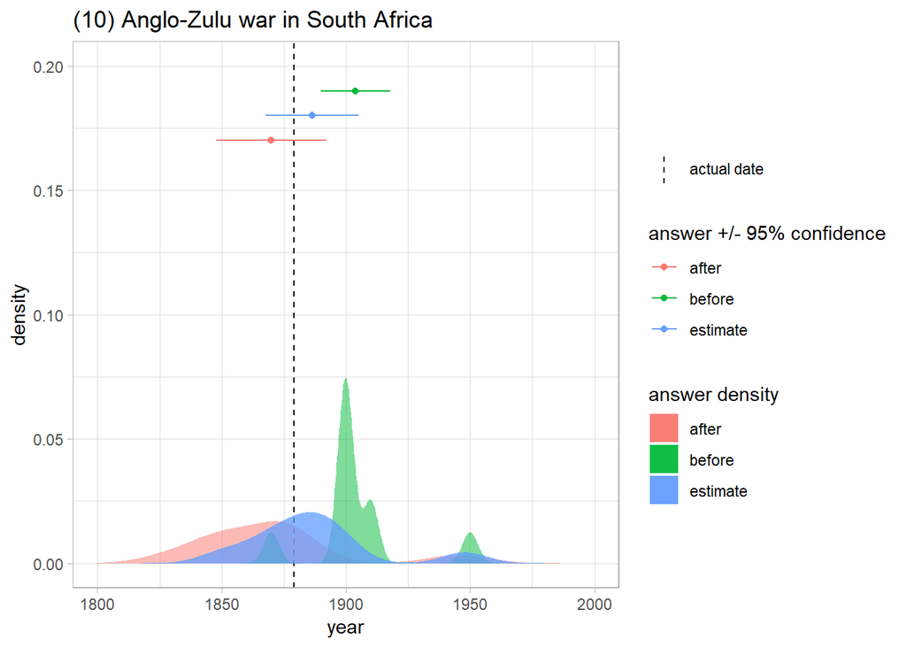

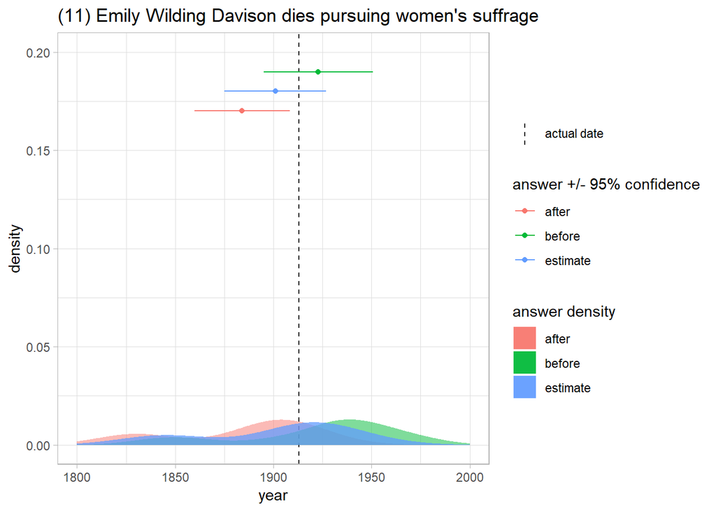

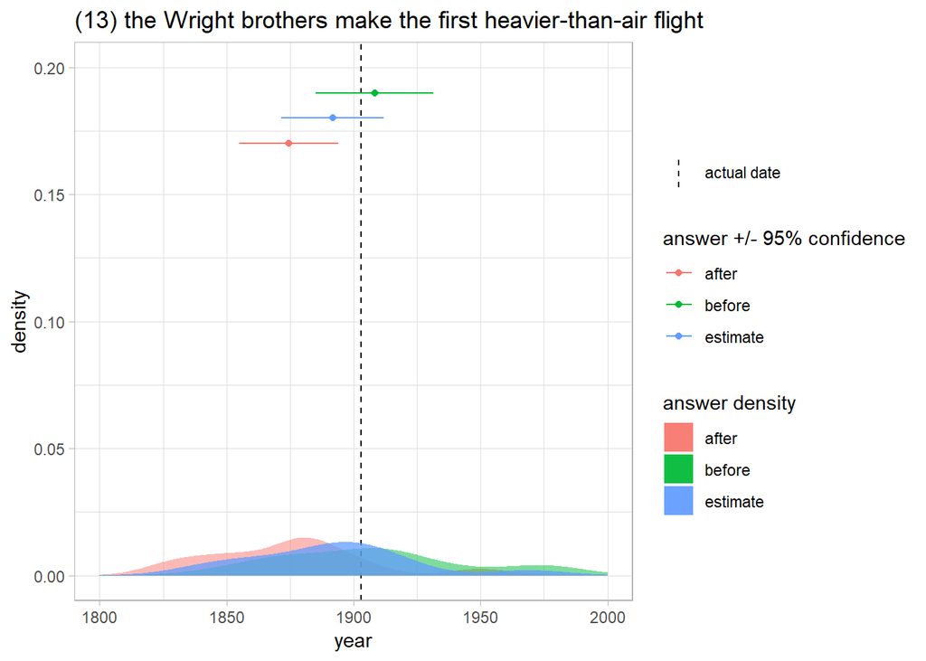

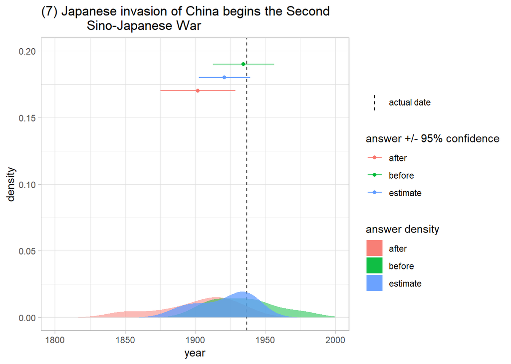

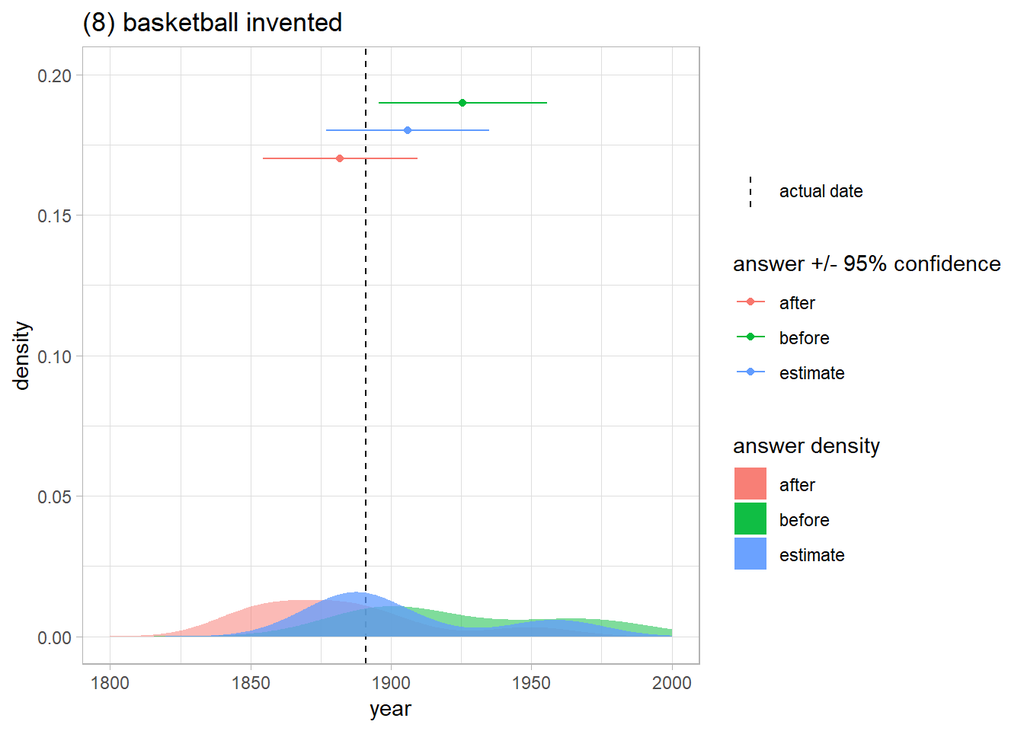

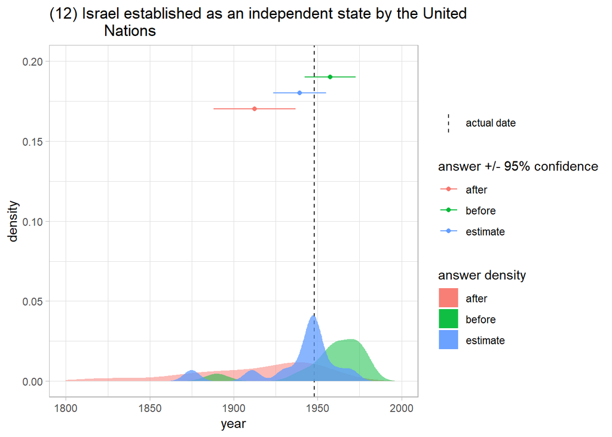

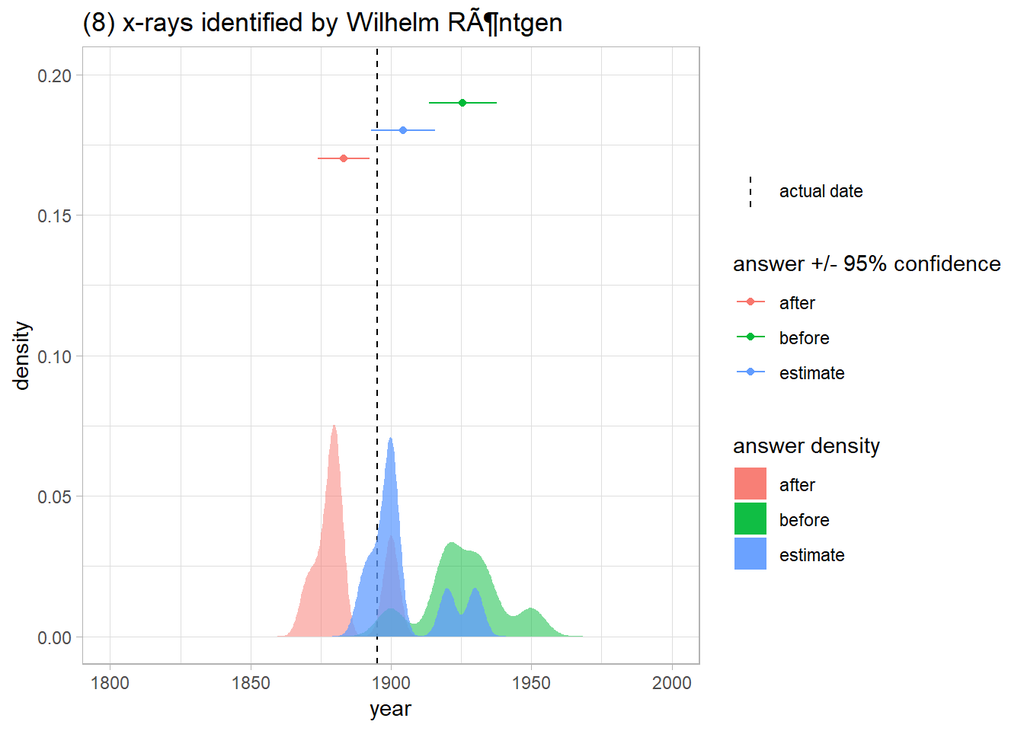

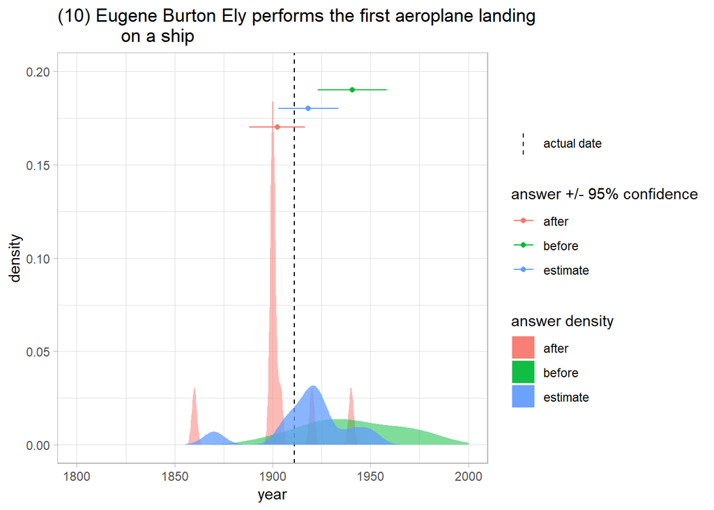

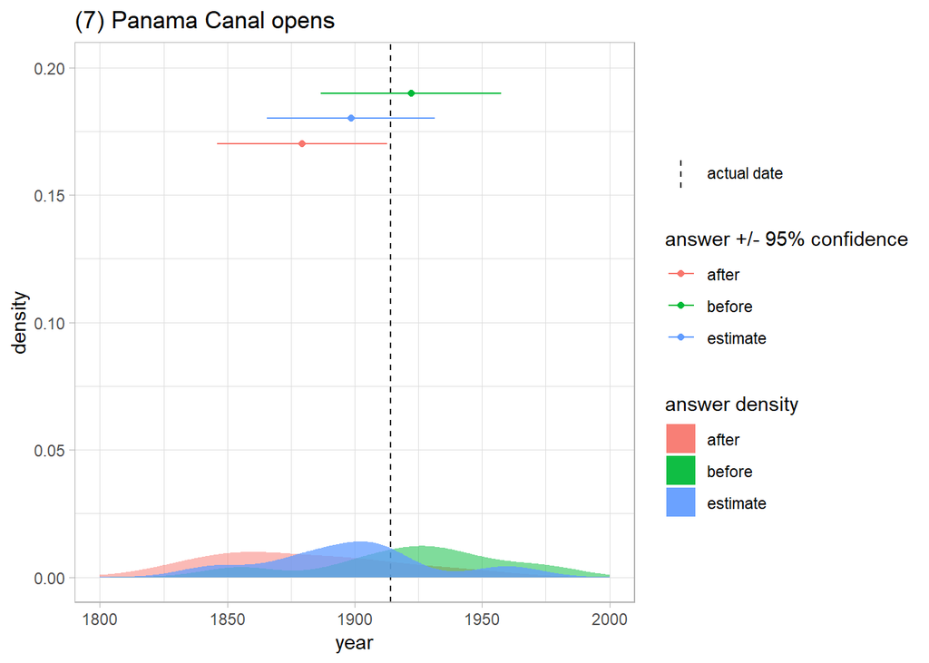

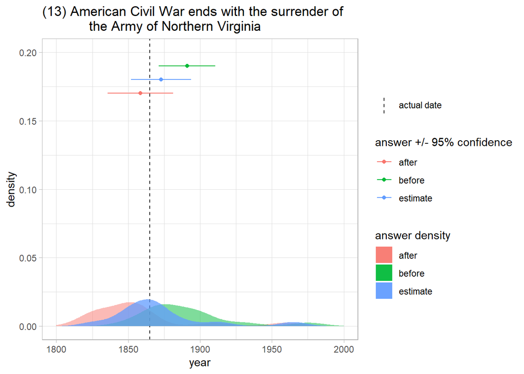

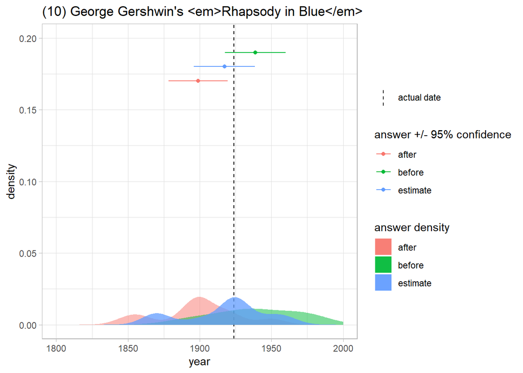

[1 more figures not shown]